# Practical

## Setting priors and model checking for Linear Models

In this excercise we will:

- Learn how to set priors for linear effects $\beta_0$ and $\beta_1$
- Learn how to set the priors for the hyperparameter $\tau = 1/\sigma^2$.
- Visualize marginal postrerior distributions
- Perform model checks for linear models

Start by loading useful libraries:

```r
library(dplyr)
library(INLA)
library(ggplot2)
library(patchwork)
library(inlabru)
```

Recall a simple linear regression model with Gaussian observations
$$y_i\sim\mathcal{N}(\mu_i, \sigma^2), \qquad i = 1,\dots,N$$

where $\sigma^2$ is the observation error, and the mean parameter $\mu_i$ is linked to the linear predictor through an identity function:
$$\eta_i = \mu_i = \beta_0 + \beta_1 x_i$$
where $x_i$ is a covariate and $\beta_0, \beta_1$ are parameters to be estimated. In INLA, we assume that the model is a latent Gaussian model, i.e., we have to assign $\beta_0$ and $\beta_1$ a Gaussian prior. For the precision hyperparameter $\tau = 1/\sigma^2$ a typical prior choice is a $\text{Gamma}(a,b)$ prior.

In `R-INLA`, the default choice of priors for each $\beta$ is

$$\beta \sim \mathcal{N}(0,10^3).$$

and the prior for the variance parameter in terms of the log precision is

$$\log(\tau) \sim \mathrm{logGamma}(1,5 \times 10^{-5})$$

**Note**

If your model uses the default intercept construction (i.e., `Intercept(1)` in the linear predictor) INLA will assign a default $\mathcal{N} (0,0)$ prior to it.

Lets see how can we change the default priors using some simulated data

#### **Simulate example data**

We simulate data from a simple linear regression model

```r
beta = c(2,0.5)
sd_error = 0.1

n = 100
x = rnorm(n)
y = beta[1] + beta[2] * x + rnorm(n, sd = sd_error)

df = data.frame(y = y, x = x)
```

#### **Fitting the linear regression model with `inlabru`**

Now we fit a simple linear regression model in `inalbru` by defining (1) the model components, (2) the linear predictor and (3) the likelihood.

```r
# Model components
cmp =  ~ -1 + beta_0(1) + beta_1(x, model = "linear")
# Linear predictor
formula = y ~ Intercept + beta_1
# Observational model likelihood
lik =  bru_obs(formula = y ~.,
            family = "gaussian",
            data = df)
# Fit the Model
fit.lm = bru(cmp, lik)
```

### Change the prior distributions

Until now, we have used the default priors for both the precision $\tau$ and the fixed effects $\beta_0$ and $\beta_1$. Let’s see how to customize these.

To check which priors are used in a fitted model one can use the function `inla.prior.used()`

```r
inla.priors.used(fit.lm)
```

```
section=[family]
    tag=[INLA.Data1] component=[gaussian]
        theta1:
            parameter=[log precision]
            prior=[loggamma]
            param=[1e+00, 5e-05]
section=[linear]
    tag=[beta_0] component=[beta_0]
        beta:
            parameter=[beta_0]
            prior=[normal]
            param=[0.000, 0.001]
    tag=[beta_1] component=[beta_1]
        beta:
            parameter=[beta_1]
            prior=[normal]
            param=[0.000, 0.001]
```

From the output we see that the precision for the observation $\tau\sim\text{Gamma}(1e+00,5e-05)$ while $\beta_0$ and $\beta_1$ have precision 0.001, that is variance $1/0.001$.

**Change the precision for the linear effects**

The precision for linear effects is set in the component definition. For example, if we want to increase the precision to 0.01 for $\beta_0$ we define the relative components as:

```r
cmp1 =  ~-1 +  beta_0(1, prec.linear = 0.01) + beta_1(x, model = "linear")
```

**Task**

Run the model again using 0.1 as default precision for both the intercept and the slope parameter.

```r
cmp2 =  ~ -1 +
          beta_0(1, prec.linear = 0.1) +
          beta_1(x, model = "linear", prec.linear = 0.1)

lm.fit2 = bru(cmp2, lik)
```

Note that we can use the same observation model as before since both the formula and the dataset are unchanged.

**Change the prior for the precision of the observation error** $\tau$

Priors on the hyperparameters of the observation model must be passed by defining argument `hyper` within `control.family` in the call to the `bru_obs()` function.

```r
# First we define the logGamma (0.01,0.01) prior

prec.tau <- list(prec = list(prior = "loggamma",   # prior name
                             param = c(0.01, 0.01))) # prior values

lik2 =  bru_obs(formula = y ~.,
                family = "gaussian",
                data = df,
                control.family = list(hyper = prec.tau))

fit.lm2 = bru(cmp2, lik2)
```

The names of the priors available in **R-INLA** can be seen with `names(inla.models()$prior)`

### Visualizing the posterior marginals

Posterior marginal distributions of the ﬁxed effects parameters and the hyperparameters can be visualized using the `plot()` function by calling the name of the component. For example, if want to visualize the posterior density of the intercept $\beta_0$ we can type:

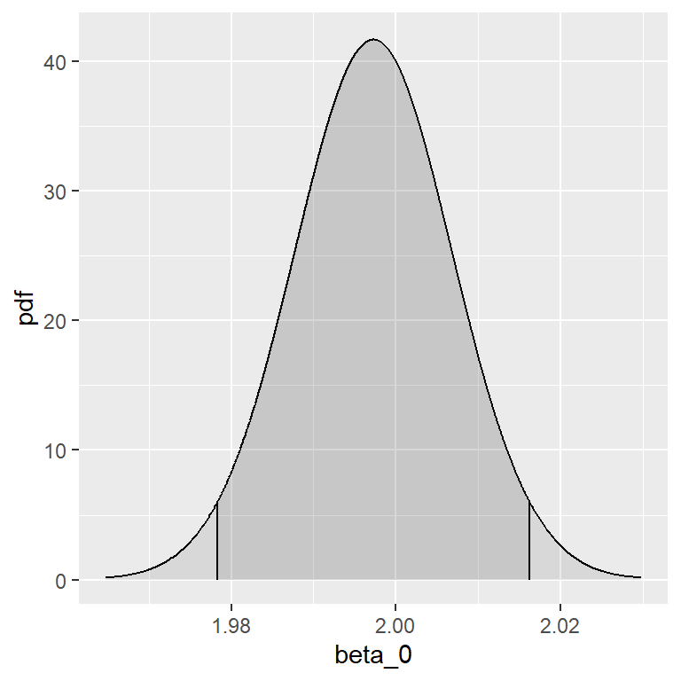

```r
plot(fit.lm, "beta_0")
```

**Task**

Plot the posterior marginals for $\beta_1$ and for the precision of the observation error $\pi(\tau|y)$

See the `summary()` output to check the names for the different model components.

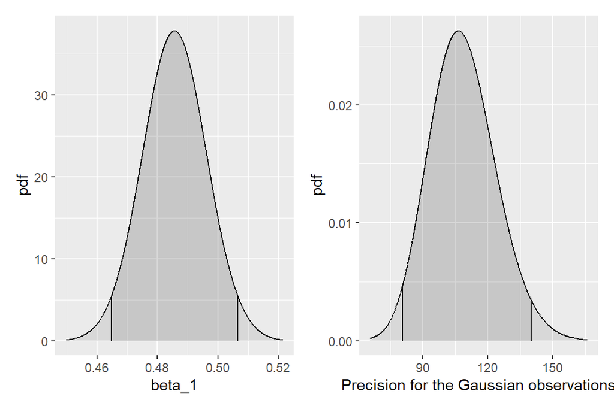

```r
plot(fit.lm, "beta_1") +
plot(fit.lm, "Precision for the Gaussian observations")
```

### Model Checking

A common way for model diagnostics in regression analysis is by checking residual plots. In a Bayesian setting residuals can be defined in multipleways depending on how you account for posterior uncertainty. Here, we will adopt a Bayesian approach by generating samples from the posterior distribution of the model parameters and then draw samples from the residuals defined as:

$$r_i = y_i - x_i^T\beta$$

We can use the `predict` function to achieve this:

```r
res_samples <- predict(
  fit.lm,         # the fitted model
  df,             # the original data set
  ~ data.frame(
    res = y-(beta_0 + beta_1)  # compute the residuals
  ),
  n.samples = 1000   # draw 1000 samples
)
```

The resulting data frame contains the posterior draw of the residuals mean for which we can produce some diagnostics plots , e.g.

**Residuals checks for Linear Model**

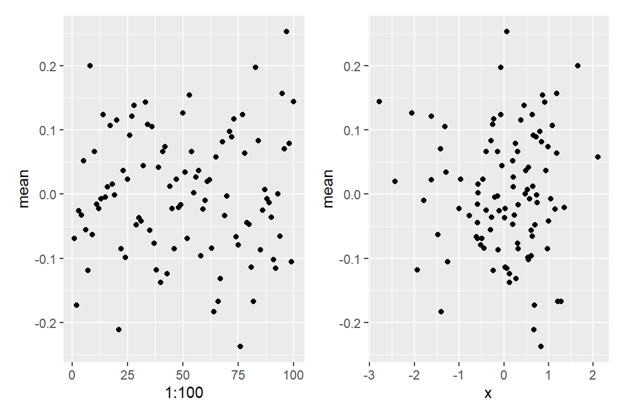

Bayesian residual plots: the left panel is the residual index plot; the right panel is the plot of the residual versus the covariate x

```r
ggplot(res_samples,aes(y=mean,x=1:100))+geom_point() +
ggplot(res_samples,aes(y=mean,x=x))+geom_point()
```

We can also compare these against the theoretical quantiles of the Normal distribution as follows:

**QQPlot for Linear Model**

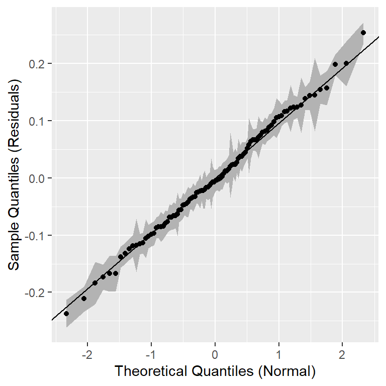

```r
arrange(res_samples, mean) %>%
  mutate(theortical_quantiles = qnorm(1:100 / (1+100))) %>%
  ggplot(aes(x=theortical_quantiles,y= mean)) +
  geom_ribbon(aes(ymin = q0.025, ymax = q0.975), fill = "grey70")+
  geom_abline(intercept = mean(res_samples$mean),
              slope = sd(res_samples$mean)) +
  geom_point() +
  labs(x = "Theoretical Quantiles (Normal)",
       y= "Sample Quantiles (Residuals)")
```